# Assignment 2 - Matrix Manipulation & Linear Systems

### 6.7)

$Y_{i}$ is the total of $i^{th}$ currency held, when all currencies are exchanged for $i$. The $i^{th}$ element in $Y$ represents the amount of money you hold in the $i^{th}$ currency, given you exchange all other currencies for the $i^{th}$ currency. This is shown through $Y = Rx$, where $Y_{i}$ is the exchange rate of currencey $j$ for currency $i$ multiplied by the amount of currency $i$ held, summed across $i$ currencies.

### 6.8)

$A$ starts as an identity matrix, where the elements in each row to the left of the $1$ are $(1+r)^{x}$, $x$ being equal to how many elements moved left from $1$.

Example:

$A = $ $\left(\begin{array}{cc} 1 & 0 & 0 & 0\\ (1+r) & 1 & 0 & 0\\ (1+r)^{2} & (1+r) & 1 & 0\\ (1+r)^{3} & (1+r)^{2} & (1+r) & 1 \end{array}\right) $

This is shown through satisfying the $b = (1+r) \cdot b_{t-1}+c_{t}$ condition, where when multiplying the matrix $A$ by the vector $c_{1}$ for each element in $b$ we sum $c_{t} \cdot 1$ and $(1+r) \cdot b_{t-1}$. Lastly, $b_{t-1}(1+r)$ can be found through writing $b_{t-1}$ in terms of $c_{1}$ and multiplying $(1+r)$ through each $c$ term.

### 6.9)

a)

$c \cdot \overrightarrow{1}$

This is because $c$ is a vector for dollars spent on each advertising channel, so $c \cdot \overrightarrow{1}$ is the total dollars spent.

b)

$v = Rc$

This is because each element in R represents impressions per dollar for each segment for each channel – when multiplied by $c$ you get: $\cfrac{impressions}{$} \cdot ({$})$ = impressions for each segment.

c)

For the $i_{th}$ row corresponding to market segment 3 in $R$, I would find the $i,j$ that is greatest, and find the channel associated with this $j$ value.

e)

The impressions per dollar spent for channel 5 for the 3rd market segment is very low; the 5th marketing channel is relatively ineffective at producing impressions for the 3rd market segment.

### 6.10)

a)

$Y = Rx$

This is because for the $i_{th}$ resource we sum the resource per job times units of job, for all the jobs, resulting in the amount of each resource that's needed.

b)

$c = R^{T}p$

This is becuase for job $j$ we sum the resource per job times price per resource, which gives us the cost per unit of job type.

### 7.15)

a)

Given:

$h*c \approx e_{i}$

$y = c*u$

$h*(c*u) = (h*c)*u$

We find:

$h*(y) = (e_{i})*u$

$z = (e_{i})*u$

Assuming the equalizer is proficient ($h*c$ is approximately equal to $e_i$), z should be approximately equal to u for each time step.

b)

```python
import numpy as np
import matplotlib.pyplot as plt
import random as rnd
```

```python
#Generate random -1, 1 array

def random_values(output_values, output_length):

    random_signal = np.random.choice(output_values, output_length, replace = True)

    return random_signal
```

```python
#Declare inputs
output_values = [-1,1]
output_length = 50

#Produce signal
random_signal = random_values(output_values, output_length)
```

```python
#Channel impulse response
c = np.array([1, .7, -.3])

#Equalizer
h = np.array([.9, -.5, .5, -.4, .3, -.3, .2, -.1])

#Receiver signal
y = np.convolve(c, random_signal)

#Equalized Receiver signal
z = np.convolve(h, y)
```

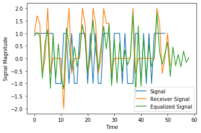

```python
#Plot signal, receiver signal, equalized signal

plt.figure()

#Signal
plt.plot(random_signal, label = 'Signal')

#Receiver signal
plt.plot(y, label = "Receiver Signal")

#Equalized signal
plt.plot(z, label = "Equalized Signal")

plt.ylabel("Signal Magnitude")
plt.xlabel("Time")
plt.legend()
plt.show()
```

### 8.4)

Given:

$x =$ $ \left(\begin{array}{cc} 1\\ 2\\ 3\\ 4\\ 5\\ 6\\ 7\\ 8\\ 9 \end{array}\right) =$ $ \left(\begin{array}{cc} 1 & 4 & 7\\ 2 & 5 & 8\\ 3 & 6 & 9\\ \end{array}\right)$

a)

$y = $ $ \left(\begin{array}{cc} 0 & 0 & 1 & 0 & 0 & 0 & 0 & 0 & 0\\ 0 & 1 & 0 & 0 & 0 & 0 & 0 & 0 & 0\\ 1 & 0 & 0 & 0 & 0 & 0 & 0 & 0 & 0\\ 0 & 0 & 0 & 0 & 0 & 1 & 0 & 0 & 0\\ 0 & 0 & 0 & 0 & 1 & 0 & 0 & 0 & 0\\ 0 & 0 & 0 & 1 & 0 & 0 & 0 & 0 & 0\\ 0 & 0 & 0 & 0 & 0 & 0 & 0 & 0 & 1\\ 0 & 0 & 0 & 0 & 0 & 0 & 0 & 1 & 0\\ 0 & 0 & 0 & 0 & 0 & 0 & 1 & 0 & 0 \end{array}\right)x $

Achieves the matrix:

$ \left(\begin{array}{cc} 3 & 6 & 9\\ 2 & 5 & 8\\ 1 & 4 & 7\\ \end{array}\right)$

b)

$y = $ $ \left(\begin{array}{cc} 0 & 0 & 1 & 0 & 0 & 0 & 0 & 0 & 0\\ 0 & 0 & 0 & 0 & 0 & 1 & 0 & 0 & 0\\ 0 & 0 & 0 & 0 & 0 & 0 & 0 & 0 & 1\\ 0 & 1 & 0 & 0 & 0 & 0 & 0 & 0 & 0\\ 0 & 0 & 0 & 0 & 1 & 0 & 0 & 0 & 0\\ 0 & 0 & 0 & 0 & 0 & 0 & 0 & 1 & 0\\ 1 & 0 & 0 & 0 & 0 & 0 & 0 & 0 & 0\\ 0 & 0 & 0 & 1 & 0 & 0 & 0 & 0 & 0\\ 0 & 0 & 0 & 0 & 0 & 0 & 1 & 0 & 0 \end{array}\right) x$

Achieves the matrix:

$ \left(\begin{array}{cc} 3 & 2 & 1\\ 6 & 5 & 4\\ 9 & 8 & 7\\ \end{array}\right)$

c)

$y = $ $ \left(\begin{array}{cc} 0 & 0 & 0 & 0 & 0 & 0 & 0 & 0 & 0\\ 0 & 0 & 0 & 0 & 0 & 0 & 0 & 0 & 0\\ 0 & 0 & 0 & 0 & 0 & 0 & 0 & 0 & 0\\ 0 & 1 & 0 & 0 & 0 & 0 & 0 & 0 & 0\\ 0 & 0 & 1 & 0 & 0 & 0 & 0 & 0 & 0\\ 0 & 0 & 0 & 0 & 0 & 0 & 0 & 0 & 0\\ 0 & 0 & 0 & 0 & 1 & 0 & 0 & 0 & 0\\ 0 & 0 & 0 & 0 & 0 & 1 & 0 & 0 & 0\\ 0 & 0 & 0 & 0 & 0 & 0 & 0 & 0 & 0 \end{array}\right) x$

Achieves the matrix:

$ \left(\begin{array}{cc} 0 & 2 & 5\\ 0 & 3 & 6\\ 0 & 0 & 0\\ \end{array}\right)$

d)

$y = $ $ \left(\begin{array}{cc} 0 & \cfrac{1}{2} & 0 & \cfrac{1}{2} & 0 & 0 & 0 & 0 & 0\\ \cfrac{1}{3} & 0 & \cfrac{1}{3} & 0 & \cfrac{1}{3} & 0 & 0 & 0 & 0\\ 0 & \cfrac{1}{2} & 0 & 0 & 0 & \cfrac{1}{2} & 0 & 0 & 0\\ \cfrac{1}{3} & 0 & 0 & 0 & \cfrac{1}{3} & 0 & \cfrac{1}{3} & 0 & 0\\ 0 & \cfrac{1}{4} & 0 & \cfrac{1}{4} & 0 & \cfrac{1}{4} & 0 & \cfrac{1}{4} & 0\\ 0 & 0 & \cfrac{1}{3} & 0 & \cfrac{1}{3} & 0 & 0 & 0 & \cfrac{1}{3}\\ 0 & 0 & 0 & \cfrac{1}{2} & 0 & 0 & 0 & \cfrac{1}{2} & 0\\ 0 & 0 & 0 & 0 & \cfrac{1}{3} & 0 & \cfrac{1}{3} & 0 & \cfrac{1}{3}\\ 0 & 0 & 0 & 0 & 0 & \cfrac{1}{2} & 0 & \cfrac{1}{2} & 0 \end{array}\right) x$

Achieves each value to be the average of its neighbors. The fraction used is chosen based on how many qualified neighbors the value has (2, 3, or 4).

### 8.16)

$A\theta = b$

$ \left(\begin{array}{cc} 1 & x_{1} & y_{1} & x_{1}y_{1}\\ 1 & x_{1} & y_{2} & x_{1}y_{2}\\ 1 & x_{2} & y_{1} & x_{2}y_{1}\\ 1 & x_{2} & y_{2} & x_{2}y_{2} \end{array}\right) $ $ \left(\begin{array}{cc} \theta_{1}\\ \theta_{2}\\ \theta_{3}\\ \theta_{4} \end{array}\right)= $ $ \left(\begin{array}{cc} F_{11}\\ F_{12}\\ F_{21}\\ F_{22} \end{array}\right) $

This A matrix satisfies the necessary conditions because:

$ \left(\begin{array}{cc} \theta_{1} + \theta_{2}x_{1} + \theta_{3}y_{1} + \theta_{4}x_{1}y_{1}\\ \theta_{1} + \theta_{2}x_{1} + \theta_{3}y_{2} + \theta_{4}x_{1}y_{2}\\ \theta_{1} + \theta_{2}x_{2} + \theta_{3}y_{1} + \theta_{4}x_{2}y_{1}\\ \theta_{1} + \theta_{2}x_{2} + \theta_{3}y_{2} + \theta_{4}x_{2}y_{2} \end{array}\right)= $ $ \left(\begin{array}{cc} F_{11}\\ F_{12}\\ F_{21}\\ F_{22} \end{array}\right) $